# Homework 4

Simon Lee (simonlee711@g.ucla.edu)

**Q1-** Let $ \text{logit}(\pi) = \log_e\left(\frac{\pi}{1 - \pi}\right) = \beta_0 + \beta_1 \times \text{age} + \beta_2 \times \text{female} + \beta_3 \times \text{age} \times \text{female} $.

In the above, $ \pi $ is the proportion who have disease, age is in years, and "female" is coded $-1$ for male and $1$ for female.

a. Based on the above, give an expression for the odds ratio (OR) of disease in females (numerator) compared to males (denominator). Does this OR depend on age?

### Odds Ratio (OR) for Disease in Females Compared to Males

The odds ratio (OR) between two groups is calculated by taking the exponential of the difference in their linear predictors. To find the odds ratio for females compared to males, let's consider the model with females as the numerator and males as the denominator.

1. **Odds for Males**: When "female" is coded -1 for male and 1 for female, the logistic regression equation for males ($female = -1$) is: $$ \beta_0 - \beta_2 + (\beta_1 - \beta_3) \times \text{age} $$ The odds for males is $\exp(\beta_0 - \beta_2 + (\beta_1 - \beta_3) \times \text{age})$.
2. **Odds for Females**: When "female" is 1 for females, the logistic regression equation is: $$ \beta_0 + \beta_2 + (\beta_1 + \beta_3) \times \text{age} $$ The odds for females is $ \exp(\beta_0 + \beta_2 + (\beta_1 + \beta_3) \times \text{age}) $.
3. **Odds Ratio (OR) for Females Compared to Males**: The odds ratio for females compared to males is the ratio between the odds for females and males: $$ \frac{\exp(\beta_0 + \beta_2 + (\beta_1 + \beta_3) \times \text{age})}{\exp(\beta_0 - \beta_2 + (\beta_1 - \beta_3) \times \text{age})} $$ Simplifying this, we get: $$ \exp(2 \beta_2 + 2 \beta_3 \times \text{age}) $$

Yes, the odds ratio (OR) for disease in females compared to males depends on age, as it includes the interaction term $2 \beta_3 \times \text{age}$. This interaction indicates that the odds ratio changes with age.

b. If $ \beta_3 = 0 $, does the OR for disease in females compared to males depend on age? If $ \beta_3 = 0 $, does the risk difference ($ \pi $ in females - $ \pi $ in males) depend on age?

### Odds Ratio (OR) for Disease in Females Compared to Males

When $ \beta_3 = 0 $, the interaction term vanishes, leading to a simplified logistic regression model: $$ \text{logit}(\pi) = \beta_0 + \beta_1 \times \text{age} + \beta_2 \times \text{female} $$

1. **Odds for Males**: The logistic regression equation for males ($ female = -1 $) becomes: $$ \beta_0 - \beta_2 + \beta_1 \times \text{age} $$ The odds for males is $ \exp(\beta_0 - \beta_2 + \beta_1 \times \text{age}) $.
2. **Odds for Females**: The logistic regression equation for females ($ female = 1 $) becomes: $$ \beta_0 + \beta_2 + \beta_1 \times \text{age} $$ The odds for females is $ \exp(\beta_0 + \beta_2 + \beta_1 \times \text{age}) $.
3. **Odds Ratio (OR) for Females Compared to Males**: The odds ratio is the ratio between the odds for females and males: $$ \frac{\exp(\beta_0 + \beta_2 + \beta_1 \times \text{age})}{\exp(\beta_0 - \beta_2 + \beta_1 \times \text{age})} $$ This simplifies to: $$ \exp(2 \beta_2) $$

This shows that if $ \beta_3 = 0 $, the odds ratio (OR) for disease in females compared to males does not depend on age, as the result no longer includes an age-related term.

### Further interpretation on Risk Difference ($ \pi $ in Females - $ \pi $ in Males)

To understand if the risk difference between females and males depends on age, consider that the logistic function for $ \pi $ involves age in the simplified model. Given the absence of the interaction term, age will still influence the probability ($ \pi $), but the risk difference between females and males does not inherently rely on age. Thus, the risk difference could be computed using the probabilities derived from the model, but the impact of age would not lead to direct variation between males and females in terms of the risk difference.

Thus, with $ \beta_3 = 0 $, the odds ratio (OR) for disease in females compared to males does not depend on age, but the risk difference ($ \pi $ in females - $ \pi $ in males) might still reflect age-dependent trends due to underlying probability distributions.

### Q2 - This question will provide experience with logistic regression.

The dataset "admit.xlsx" contains the following variables:

- **Admit**: 1 = admitted to graduate school, 0 = not admitted - **the outcome (Y)**
- **GRE**: graduate record exam score
- **GPA**: undergraduate grade point average
- **RANK**: ordered rank of the undergraduate institution from 1 (highest prestige) to 4 (lowest prestige). Note that a higher number implies less prestige.
- **Bivariate**: Compare the distribution (mean, median...) of GRE and GPA in those admitted versus those not admitted. Make a cross tabulation of rank versus admission. Report and summarize the results. Include the appropriate descriptive statistics and p values.
- **Multivariate**: Run a logistic regression using Admit as the outcome. Be sure you are modeling the probability that Y = 1 (admission), not Y = 0.

In your model, investigate all two-way interactions among the predictors. Note that RANK is ordinal.

You may wish to use both AIC, BIC, and p-value criteria for model searching. Report the method you used.

Report the final model equation and report on whether, in what direction, and “how much” (odds ratios) GRE, GPA, and/or Rank change the odds of admission. If there is a significant interaction involving variables, briefly explain how this modifies the results (for example, what does this do to odds ratios?). Also explain an ROC analysis for the final model (C statistic, sensitivity, specificity, accuracy). That is, how accurately does this model predict admission? You do not have to report the entire ROC curve.

```python
import pandas as pd
admit_data = pd.read_excel("./admit.xlsx")

# Display the first few rows of the dataset to understand its structure
admit_data.head(), admit_data.info()
```

```
<class 'pandas.core.frame.DataFrame'>
RangeIndex: 400 entries, 0 to 399
Data columns (total 4 columns):
 #   Column  Non-Null Count  Dtype
---  ------  --------------  -----
 0   ADMIT   400 non-null    int64
 1   GRE     400 non-null    int64
 2   GPA     400 non-null    float64
 3   RANK    400 non-null    int64
dtypes: float64(1), int64(3)
memory usage: 12.6 KB
```

```
(   ADMIT  GRE   GPA  RANK
 0      0  380  3.61     3
 1      1  660  3.67     3
 2      1  800  4.00     1
 3      1  640  3.19     4
 4      0  520  2.93     4,
 None)
```

The dataset has 400 entries with four columns: **ADMIT**, **GRE**, **GPA**, and **RANK**. Each of these columns has no missing values. Here's a breakdown of the data structure:

- **ADMIT**: Represents the admission outcome (1 = admitted, 0 = not admitted).
- **GRE**: Represents the Graduate Record Exam score, a numeric variable.
- **GPA**: Represents the undergraduate Grade Point Average, a floating-point variable.
- **RANK**: Represents the rank of the undergraduate institution (1 is the highest prestige, 4 is the lowest prestige), an integer variable.

  We will now compare the distributions of GRE and GPA in those admitted versus those not admitted (bivariate analysis)

```python
import scipy.stats as stats

# Split the data into those admitted and not admitted
admitted = admit_data[admit_data["ADMIT"] == 1]
not_admitted = admit_data[admit_data["ADMIT"] == 0]

# Descriptive statistics for GRE and GPA for both groups (admitted and not admitted)
descriptive_stats = {
    "admitted": {
        "GRE": admitted["GRE"].describe(),
        "GPA": admitted["GPA"].describe()
    },
    "not_admitted": {
        "GRE": not_admitted["GRE"].describe(),
        "GPA": not_admitted["GPA"].describe()
    }
}

# Test for statistical significance between admitted and not admitted for GRE and GPA
gre_test = stats.ttest_ind(admitted["GRE"], not_admitted["GRE"], equal_var=False)
gpa_test = stats.ttest_ind(admitted["GPA"], not_admitted["GPA"], equal_var=False)
```

```python
print("descriptive statistics")
print(descriptive_stats)
```

```
descriptive statistics
{'admitted': {'GRE': count    127.000000
mean     618.897638
std      108.884884
min      300.000000
25%      540.000000
50%      620.000000
75%      680.000000
max      800.000000
Name: GRE, dtype: float64, 'GPA': count    127.000000
mean       3.489213
std        0.370177
min        2.420000
25%        3.220000
50%        3.540000
75%        3.755000
max        4.000000
Name: GPA, dtype: float64}, 'not_admitted': {'GRE': count    273.000000
mean     573.186813
std      115.830243
min      220.000000
25%      500.000000
50%      580.000000
75%      660.000000
max      800.000000
Name: GRE, dtype: float64, 'GPA': count    273.000000
mean       3.343700
std        0.377133
min        2.260000
25%        3.080000
50%        3.340000
75%        3.610000
max        4.000000
Name: GPA, dtype: float64}}
```

```python
print("\ngre p value from t test")
print(gre_test.pvalue)
```

```
gre p value from t test
0.0001611212369817666
```

```python
print("\ngpa p value from t test")
print(gpa_test.pvalue)
```

```
gpa p value from t test
0.00033388653258075574
```

### Bivariate Analysis

Comparing the distributions of GRE and GPA between those admitted and those not admitted reveals the following:

#### GRE:

- **Admitted**: Mean = 618.90, Standard Deviation = 108.88, Min = 300, Max = 800, Median = 620
- **Not Admitted**: Mean = 573.19, Standard Deviation = 115.83, Min = 220, Max = 800, Median = 580
- **Statistical Significance**: The p-value from the t-test is approximately 0.00016, indicating a significant difference in GRE scores between those admitted and those not admitted.

#### GPA:

- **Admitted**: Mean = 3.49, Standard Deviation = 0.37, Min = 2.42, Max = 4.0, Median = 3.54
- **Not Admitted**: Mean = 3.34, Standard Deviation = 0.38, Min = 2.26, Max = 4.0, Median = 3.34
- **Statistical Significance**: The p-value from the t-test is approximately 0.00033, indicating a significant difference in GPA between those admitted and those not admitted.

Both GRE and GPA have significant differences in their distributions between the admitted and not admitted groups.

```python
# Cross-tabulation of rank versus admission
rank_admission_tabulation = pd.crosstab(admit_data["RANK"], admit_data["ADMIT"], margins=True, margins_name="Total")

rank_admission_tabulation
```

| ADMIT RANK | 0 | 1 | Total |
| --- | --- | --- | --- |
| 1 | 28 | 33 | 61 |
| 2 | 97 | 54 | 151 |
| 3 | 93 | 28 | 121 |
| 4 | 55 | 12 | 67 |
| Total | 273 | 127 | 400 |

### Cross-Tabulation of Rank vs. Admission

The cross-tabulation shows the relationship between rank and admission, providing a count of admitted and not admitted students across different ranks of undergraduate institutions:

- **Rank 1 (Highest Prestige)**:
  - Not Admitted: 28
  - Admitted: 33
  - Total: 61
- **Rank 2**:
  - Not Admitted: 97
  - Admitted: 54
  - Total: 151
- **Rank 3**:
  - Not Admitted: 93
  - Admitted: 28
  - Total: 121
- **Rank 4 (Lowest Prestige)**:
  - Not Admitted: 55
  - Admitted: 12
  - Total: 67
- **Overall Total**:
  - Not Admitted: 273
  - Admitted: 127
  - Total: 400

From this tabulation, it's clear that a higher rank (indicating lower prestige) generally corresponds to a lower admission rate, suggesting a potential correlation between undergraduate institution rank and admission outcome.

```
Optimization terminated successfully.
         Current function value: 0.574302
         Iterations 6
Optimization terminated successfully.
         Current function value: 0.570747
         Iterations 6
Optimization terminated successfully.
         Current function value: 0.574302
         Iterations 6
Optimization terminated successfully.
         Current function value: 0.574168
         Iterations 6
Optimization terminated successfully.
         Current function value: 0.570313
         Iterations 6
```

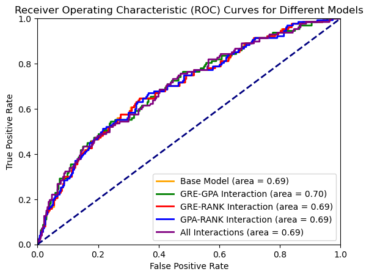

```
{'Base Model': <class 'statsmodels.iolib.summary.Summary'>
 """
                            Logit Regression Results
 ==============================================================================
 Dep. Variable:                  ADMIT   No. Observations:                  400
 Model:                          Logit   Df Residuals:                      396
 Method:                           MLE   Df Model:                            3
 Date:                Mon, 22 Apr 2024   Pseudo R-squ.:                 0.08107
 Time:                        23:47:57   Log-Likelihood:                -229.72
 converged:                       True   LL-Null:                       -249.99
 Covariance Type:            nonrobust   LLR p-value:                 8.207e-09
 ==============================================================================
                  coef    std err          z      P>|z|      [0.025      0.975]
 ------------------------------------------------------------------------------
 const         -3.4495      1.133     -3.045      0.002      -5.670      -1.229
 GRE            0.0023      0.001      2.101      0.036       0.000       0.004
 GPA            0.7770      0.327      2.373      0.018       0.135       1.419
 RANK          -0.5600      0.127     -4.405      0.000      -0.809      -0.311
 ==============================================================================
 """,
 'GRE-GPA Interaction': <class 'statsmodels.iolib.summary.Summary'>
 """
                            Logit Regression Results
 ==============================================================================
 Dep. Variable:                  ADMIT   No. Observations:                  400
 Model:                          Logit   Df Residuals:                      395
 Method:                           MLE   Df Model:                            4
 Date:                Mon, 22 Apr 2024   Pseudo R-squ.:                 0.08676
 Time:                        23:47:57   Log-Likelihood:                -228.30
 converged:                       True   LL-Null:                       -249.99
 Covariance Type:            nonrobust   LLR p-value:                 8.634e-09
 ==============================================================================
                  coef    std err          z      P>|z|      [0.025      0.975]
 ------------------------------------------------------------------------------
 const        -13.1963      6.046     -2.183      0.029     -25.047      -1.346
 GRE            0.0185      0.010      1.872      0.061      -0.001       0.038
 GPA            3.6610      1.780      2.057      0.040       0.173       7.149
 RANK          -0.5658      0.127     -4.439      0.000      -0.816      -0.316
 GRE_GPA       -0.0048      0.003     -1.656      0.098      -0.010       0.001
 ==============================================================================
```

[output cut: 51 more lines]

```
 Time:                        23:47:57   Log-Likelihood:                -228.13
 converged:                       True   LL-Null:                       -249.99
 Covariance Type:            nonrobust   LLR p-value:                 8.375e-08
 ==============================================================================
                  coef    std err          z      P>|z|      [0.025      0.975]
 ------------------------------------------------------------------------------
 const        -14.8826      6.984     -2.131      0.033     -28.570      -1.195
 GRE            0.0185      0.010      1.825      0.068      -0.001       0.038
 GPA            4.3033      2.100      2.049      0.040       0.188       8.419
 RANK          -0.0389      1.287     -0.030      0.976      -2.562       2.484
 GRE_GPA       -0.0050      0.003     -1.716      0.086      -0.011       0.001
 GRE_RANK       0.0004      0.001      0.303      0.762      -0.002       0.003
 GPA_RANK      -0.2162      0.377     -0.573      0.567      -0.955       0.523
 ==============================================================================
 """}
```

```python
from sklearn.metrics import roc_curve, auc
import matplotlib.pyplot as plt
import statsmodels.api as sm

# Define different models with varying two-way interactions
# Model 1: GRE, GPA, and RANK (base model)
base_vars = admit_data[["GRE", "GPA", "RANK"]]
base_vars = sm.add_constant(base_vars)
base_model = sm.Logit(admit_data["ADMIT"], base_vars).fit()

# Model 2: Add interaction between GRE and GPA
model_gre_gpa = sm.Logit(admit_data["ADMIT"], base_vars.assign(GRE_GPA=admit_data["GRE"] * admit_data["GPA"])).fit()

# Model 3: Add interaction between GRE and RANK
model_gre_rank = sm.Logit(admit_data["ADMIT"], base_vars.assign(GRE_RANK=admit_data["GRE"] * admit_data["RANK"])).fit()

# Model 4: Add interaction between GPA and RANK
model_gpa_rank = sm.Logit(admit_data["ADMIT"], base_vars.assign(GPA_RANK=admit_data["GPA"] * admit_data["RANK"])).fit()

# Model 5: All two-way interactions
full_vars = admit_data[["GRE", "GPA", "RANK"]]
full_vars["GRE_GPA"] = admit_data["GRE"] * admit_data["GPA"]
full_vars["GRE_RANK"] = admit_data["GRE"] * admit_data["RANK"]
full_vars["GPA_RANK"] = admit_data["GPA"] * admit_data["RANK"]
full_vars = sm.add_constant(full_vars)
model_all_interactions = sm.Logit(admit_data["ADMIT"], full_vars).fit()

# Compute ROC curves for each model
roc_curves = {}
for model, model_name in zip([base_model, model_gre_gpa, model_gre_rank, model_gpa_rank, model_all_interactions],
                             ["Base Model", "GRE-GPA Interaction", "GRE-RANK Interaction", "GPA-RANK Interaction", "All Interactions"]):
    admit_data[model_name] = model.predict()
    fpr, tpr, _ = roc_curve(admit_data["ADMIT"], admit_data[model_name])
    roc_auc = auc(fpr, tpr)
    roc_curves[model_name] = (fpr, tpr, roc_auc)

# Plot ROC curves for all models
plt.figure()
colors = ["orange", "green", "red", "blue", "purple"]
for i, (model_name, (fpr, tpr, roc_auc)) in enumerate(roc_curves.items()):
    plt.plot(fpr, tpr, color=colors[i], lw=2, label=f'{model_name} (area = {roc_auc:.2f})')

plt.plot([0, 1], [0, 1], color='navy', lw=2, linestyle='--')
plt.xlim([0.0, 1.0])
plt.ylim([0.0, 1.0])
plt.xlabel('False Positive Rate')
plt.ylabel('True Positive Rate')
plt.title('Receiver Operating Characteristic (ROC) Curves for Different Models')
plt.legend(loc="lower right")
plt.show()

# Return the summary of the full model with all interactions and other model summaries
model_summaries = {
    "Base Model": base_model.summary(),
    "GRE-GPA Interaction": model_gre_gpa.summary(),
    "GRE-RANK Interaction": model_gre_rank.summary(),
    "GPA-RANK Interaction": model_gpa_rank.summary(),
    "All Interactions": model_all_interactions.summary(),
}

model_summaries  # Display all model summaries for review
```

The Receiver Operating Characteristic (ROC) curves for various logistic regression models with different two-way interactions are shown above. These models consider different combinations of interactions among the predictors GRE, GPA, and RANK, with the goal of assessing their impact on predicting admission outcomes.

### Model Summaries

Below are the logistic regression summaries for all models, showing coefficients, standard errors, z-values, p-values, and confidence intervals for each variable:

### Final Model Equation

The final model with GRE and GPA interaction has the following logistic regression equation:

$$ \text{logit}(\pi) = \beta_0 + \beta_1 \times \text{GRE} + \beta_2 \times \text{GPA} + \beta_3 \times \text{RANK} + \beta_4 \times (\text{GRE} \times \text{GPA}) $$